# Integrated serologic surveillance of population immunity and disease transmission

Computational notebook

April 20, 2018

# Summary

This notebook conducts the analyses and creates the figures for the Perspective:

Arnold BF, Scobie HM, Priest JW, Lammie PJ. Integrated serologic surveillance of population immunity and disease transmission. *Emerging Infectious Diseases* 2018; https://doi.org/10.3201/eid2407.171928

To download the R markdown source code for this notebook, toggle the dropdown menu at the top right of this page to “Download Rmd”.

## Preamble

```r
# Preamble - load packages and save colors for plotting
rm(list=ls())
# Machine learning and TMLE packages
library(SuperLearner)
```

```r
library(tmle)
```

```r
# this is a development package on GitHub: https://github.com/ben-arnold/tmleAb
library(tmleAb)
```

```r
library(foreach)
```

```r
# dm and data visualization
library(tidyverse)
```

```r
library(scales)
```

```r
library(ellipse)
library(RColorBrewer)
# bright color blind palette:  https://personal.sron.nl/~pault/
cblack <- "#000004FF"
cblue <- "#3366AA"
cteal <- "#11AA99"
cgreen <- "#66AA55"
cchartr <- "#CCCC55"
cmagent <- "#992288"
cred <- "#EE3333"
corange <- "#EEA722"
cyellow <- "#FFEE33"
cgrey <- "#777777"
```

# Load and process data

These data are publicly available through the Open Science Framework: https://osf.io/2kr8b/

To run this notebook, create a /data/ subdirectory and save the .rds file there. The OSF repository includes a codebook that describes the contents of the dataset.

For additional background on the serosurvey and study that collected these antibody measurements, please see:

Mao B, Chheng K, et al. Immunity to polio, measles and rubella in women of child-bearing age and estimated congenital rubella syndrome incidence, Cambodia, 2012. *Epidemiol Infect.* 2015;143: 1858–1867. https://www.ncbi.nlm.nih.gov/pubmed/25373419

Scobie HM, Mao B, et al. Tetanus Immunity among Women Aged 15 to 39 Years in Cambodia: a National Population-Based Serosurvey, 2012. *Clin Vaccine Immunol.* 2016;23: 546–554. https://www.ncbi.nlm.nih.gov/pubmed/27053629

Priest JW, Jenks MH, et al. Integration of Multiplex Bead Assays for Parasitic Diseases into a National, Population-Based Serosurvey of Women 15-39 Years of Age in Cambodia. *PLoS Negl Trop Dis.* 2016;10: e0004699. https://www.ncbi.nlm.nih.gov/pubmed/27136913

```r
#----------------------------------
# load the dataset
#----------------------------------
d <- readRDS("~/serosurveillance-cambodia/data/cambodia_serology_public.rds")
# recode 4 observations with negative
# values to 1
table(d$ttmb<=0)
```

```
FALSE  TRUE
 2146     4
```

```r
d$ttmb[d$ttmb<=0] <- 1
# create an indicator of positive based on
# the multiplex bead assay. This cutoff of 100 MFI
# was established in:
# Scobie HM, Mao B, et al. Clin Vaccine Immunol. 2016;23:546–54.
# PubMed http://dx.doi.org/10.1128/CVI.00052-16
d$ttpos <- ifelse(d$ttmb>100,1,0)
# create an indicator for parous vs nulliparus
d$parous <- ifelse(d$parity=='1:Parous',1,0)
# create an age category variable
d$agecat <- cut(d$age,breaks=c(14,19,24,29,34,39))
```

# Tetanus analysis

This analysis examines antibody levels to tetanus toxin by age and parity. It also summarizes the proportion of women by age group who are classified as seroprotected (MFI>100).

## Age-dependent mean curves

Estimate the age-dependent mean tetanus response by parity using a flexible, ensemble approach. The methodology is described in more detail in:

Arnold BF, et al. *PLoS Negl Trop Dis.* 2017;11:e0005616. PubMed: http://dx.doi.org/10.1371/journal.pntd.0005616

In this analysis, we use an ensemble machine learning approach to estimate the mean by age. The ensemble includes the simple mean, generalized linear models, smoothing splines within a generalized additive model, locally weighted regression (LOESS), random forest, and polynomial adaptive regression splines. Fit age-dependent means separately for parous and nulliparous women.

```r
#----------------------------------
# estimate the quantiative
# age-dependent antibody
# curve for tetanus toxiod,
# stratified by parity
#----------------------------------
SL.library <- c("SL.mean","SL.glm","SL.gam","SL.loess","SL.randomForest","SL.polymars")
set.seed(987325)
pacurve <- agecurveAb(Y=log10(d$ttmb[d$parity=='1:Parous']),Age=d$age[d$parity=='1:Parous'],
                      W=subset(d,parity=='1:Parous',select=c("region")),
                      id=d$psuid[d$parity=='1:Parous'],
                      SL.library=SL.library)
```

```
Summary of SuperLearner cross validated risk and
weights for algorithms included in the library:

                           CV-Risk      Coef
SL.mean_All              0.5532984 0.0000000
SL.glm_All               0.5331037 0.0000000
SL.gam.df7_All           0.4398759 0.6177253
SL.loess_All             0.4417065 0.2598030
SL.randomForest.ns40_All 0.4805953 0.0000000
SL.polymars_All          0.4726172 0.1224716
```

```r
set.seed(987325)
npcurve <- agecurveAb(Y=log10(d$ttmb[d$parity=='2:Nulliparous']),Age=d$age[d$parity=='2:Nulliparous'],
                      W=subset(d,parity=='2:Nulliparous',select=c("region")),
                      id=d$psuid[d$parity=='2:Nulliparous'],
                      SL.library=SL.library)
```

```
Summary of SuperLearner cross validated risk and
weights for algorithms included in the library:

                          CV-Risk       Coef
SL.mean_All              1.908416 0.03090276
SL.glm_All               1.754372 0.00000000
SL.gam.df3_All           1.691976 0.46447777
SL.loess_All             1.705104 0.25017107
SL.randomForest.ns25_All 1.765410 0.00000000
SL.polymars_All          1.700989 0.25444840
```

The coefficient weights in the library show that the predictions are based mainly on splines, loess, and MARS, which had the lowest cross-validate mean squared error (“risk”) in this particular analysis.

## Age-stratified seroprevalence by parity.

Below, we transform quantitative antibody levels to seropositive indicators using a cutoff >100 MFI, established in:

Scobie HM, Mao B, et al.*Clin Vaccine Immunol.* 2016;23:546–54. PubMed http://dx.doi.org/10.1128/CVI.00052-16

We use targeted maximum likelihood estimation with influence-curve based standard errors that are clustered on the 100 sampling units in the survey (`id=psuid`). The means are flexibly adjusted for age and region using an ensemble with generalized linear models and splines in a generalized additive model. We could use a more extensive library in the ensemble, but since the adjustment covariates are not high dimensional there is little gained from a larger library.

```r
#----------------------------------
# estimate seroprevalence
# by parity and age group
#----------------------------------
# count of obs in strata and crude means
Nobs <- tapply(d$ttpos,list(d$agecat,d$parity),function(x) length(x))
Nobs
```

```
        1:Parous 2:Nulliparous
(14,19]       48           387
(19,24]      224           244
(24,29]      395            88
(29,34]      397            52
(34,39]      292            23
```

```r
prevs <- tapply(d$ttpos,list(d$agecat,d$parity),function(x) mean(x,na.rm=T))
prevs
```

```
         1:Parous 2:Nulliparous
(14,19] 0.5625000     0.6124031
(19,24] 0.9553571     0.7663934
(24,29] 0.9670886     0.8863636
(29,34] 0.9949622     0.8653846
(34,39] 0.9657534     0.7826087
```

```r
# reduced library to just estimate simple means flexibly adjusted for age and region
# w/ correct CIs that account for clustering
SL.library <- c("SL.mean","SL.glm","SL.gam")
agecats <- levels(d$agecat)
set.seed(987325)
EYxp_p <- sapply(agecats,function (x) tmleAb(Y=d$ttpos[d$parity=='1:Parous' & d$agecat==x],
                                            W=subset(d,parity=='1:Parous' & agecat==x,select=c("age","region")),
                                            id=d$psuid[d$parity=='1:Parous' & d$agecat==x],
                                            SL.library=SL.library)[c("psi","se","lb","ub")])
```

```
prediction from a rank-deficient fit may be misleadingprediction from a rank-deficient fit may be misleading
```

```
 Population Mean
   Parameter Estimate:  0.5625
   Estimated Variance:  0.0070565
              p-value:  2.1389e-11
    95% Conf Interval: (0.39785, 0.72715)
 Population Mean
   Parameter Estimate:  0.95536
   Estimated Variance:  0.00034452
              p-value:  <2e-16
    95% Conf Interval: (0.91898, 0.99174)
 Population Mean
   Parameter Estimate:  0.96709
   Estimated Variance:  8.2734e-05
              p-value:  <2e-16
    95% Conf Interval: (0.94926, 0.98492)
 Population Mean
   Parameter Estimate:  0.99496
   Estimated Variance:  6.2286e-06
              p-value:  <2e-16
    95% Conf Interval: (0.99007, 0.99985)
 Population Mean
   Parameter Estimate:  0.96575
   Estimated Variance:  0.00023361
              p-value:  <2e-16
    95% Conf Interval: (0.9358, 0.99571)
```

```r
set.seed(987325)
EYxp_n <- sapply(agecats,function (x) tmleAb(Y=d$ttpos[d$parity=='2:Nulliparous' & d$agecat==x],
                                            W=subset(d,parity=='2:Nulliparous' & agecat==x,select=c("age","region")),
                                            id=d$psuid[d$parity=='2:Nulliparous' & d$agecat==x],
                                            SL.library=SL.library)[c("psi","se","lb","ub")])
```

```
 Population Mean
   Parameter Estimate:  0.6124
   Estimated Variance:  0.00119
              p-value:  <2e-16
    95% Conf Interval: (0.54479, 0.68002)
 Population Mean
   Parameter Estimate:  0.76639
   Estimated Variance:  0.0013742
              p-value:  <2e-16
    95% Conf Interval: (0.69374, 0.83905)
 Population Mean
   Parameter Estimate:  0.88636
   Estimated Variance:  0.0010415
              p-value:  <2e-16
    95% Conf Interval: (0.82311, 0.94962)
 Population Mean
   Parameter Estimate:  0.86538
   Estimated Variance:  0.0027472
              p-value:  <2e-16
    95% Conf Interval: (0.76265, 0.96812)
 Population Mean
   Parameter Estimate:  0.78261
   Estimated Variance:  0.0085197
              p-value:  <2e-16
    95% Conf Interval: (0.6017, 0.96352)
```

```r
set.seed(987325)
EYxp_diff <- sapply(agecats,function (x) tmleAb(Y=d$ttpos[d$agecat==x],
                                               X=d$parous[d$agecat==x],
                                               W=subset(d,agecat==x,select=c("age","region")),
                                               id=d$psuid[d$agecat==x],
                                               SL.library=SL.library)[c("psi","se","lb","ub","p")])
```

```
 Additive Effect
   Parameter Estimate:  -0.1638
   Estimated Variance:  0.0092456
              p-value:  0.088478
    95% Conf Interval: (-0.35226, 0.024665)
 Additive Effect
   Parameter Estimate:  0.17512
   Estimated Variance:  0.0014482
              p-value:  4.1884e-06
    95% Conf Interval: (0.10054, 0.24971)
 Additive Effect
   Parameter Estimate:  0.080707
   Estimated Variance:  0.0015349
              p-value:  0.039399
    95% Conf Interval: (0.0039175, 0.1575)
 Additive Effect
   Parameter Estimate:  0.12332
   Estimated Variance:  0.0014446
              p-value:  0.0011762
    95% Conf Interval: (0.048825, 0.19782)
 Additive Effect
   Parameter Estimate:  0.19522
   Estimated Variance:  0.013968
              p-value:  0.098579
    95% Conf Interval: (-0.036427, 0.42686)
```

## Figure of results

This is Figure 1 in the manuscript, created in base R graphics. The left panel includes the raw data plus age-dependent means, stratified by parity. The right panel includes age- and parity- stratified mean seroprevalence, with 95% confidence intervals. There is a hidden code chunk that saves a PDF version (download the .Rmd file from the top of this notebook for the full source code).

```r
lo <- layout(mat=matrix(1:2,nrow=1,ncol=2),widths=c(1,1))
cols=c(cblue,cgreen)
## Age dependent mean response
# jitter the ages just a little to improve visualization
ytics <- 0:5
xtics <- seq(15,40,by=5)
op <-par(mar=c(4,4,2,4)+0.1,xpd=T)
plot(1,1,type="n",yaxt="n",xaxt="n",bty="n",ylim=c(0,5),xlim=range(xtics),xlab="",ylab="")
axis(2,at=ytics,labels=c(
  expression(10^0),
  expression(10^1),
  expression(10^2),
  expression(10^3),
  expression(10^4),
  expression(10^5)), las=1,cex.axis=1.25)
```

```r
axis(1,at=xtics,las=1,cex.axis=1.25)
mtext("Age (years)",side=1,line=2.5,las=1)
```

```r
mtext("Luminex response (MFI-bg)",side=2,line=3)
mtext("Tetanus age-dependent mean response",side=3,line=0,adj=0)
```

```r
# parous
points(jitter(pacurve$Age),pacurve$Y,pch=16,cex=0.5,col=alpha(cols[1],alpha=0.3))
lines(pacurve$Age,pacurve$pY,col=cols[1])
```

```r
# nulliparous
points(jitter(npcurve$Age),npcurve$Y,pch=16,cex=0.5,col=alpha(cols[2],alpha=0.3))
lines(npcurve$Age,npcurve$pY,col=cols[2])
```

```r
# group labels
text(40,pacurve$pY[length(pacurve$pY)],"Parous", col=cols[1],cex=1,adj=0)
text(40,npcurve$pY[length(npcurve$pY)],"Nulliparous", col=cols[2],cex=1,adj=0)
```

```r
## Seroprotection by age category
ytics <- seq(0,1,by=0.2)
op <-par(mar=c(4,4,2,1)+0.1)
xc <- 1:5
x1s <- xc-0.1
x2s <- xc+0.1
plot(xc,xc,type="n",yaxt="n",xaxt="n",bty="n",ylim=c(0,1),xlim=c(0.5,5.5),xlab="",ylab="")
```

```r
axis(2,at=ytics,labels=sprintf("%1.0f",ytics*100),las=1)
mtext(c("15-19","20-24","25-29","30-34","35-39"),at=xc,side=1,line=1,las=1,cex=1.1)
```

```r
mtext("Age category (years)",side=1,line=2.5,las=1)
mtext("Seroprotected (%)",side=2,line=2.5)
```

```r
mtext("Tetanus seroprotected (%)",side=3,line=0,adj=0)
arrows(x0=x1s,y0=unlist(EYxp_p[3,]),y1=unlist(EYxp_p[4,]),angle=90,length=0.05,code=3,col=cols[1])
```

```r
points(x1s,unlist(EYxp_p[1,]),pch=19,bg="white",col=cols[1])
arrows(x0=x2s,y0=unlist(EYxp_n[3,]),y1=unlist(EYxp_n[4,]),angle=90,length=0.05,code=3,col=cols[2])
```

```r
points(x2s,unlist(EYxp_n[1,]),pch=21,bg="white",col=cols[2])
# group labels
text(x=x1s[2],y=unlist(EYxp_p[1,2]),"Parous", col=cols[1],cex=1,pos=2,adj=1)
```

```r
text(x=x2s[1],y=unlist(EYxp_n[1,1]),"Nulliparous",col=cols[2],cex=1,pos=4,adj=0)
par(op)
```

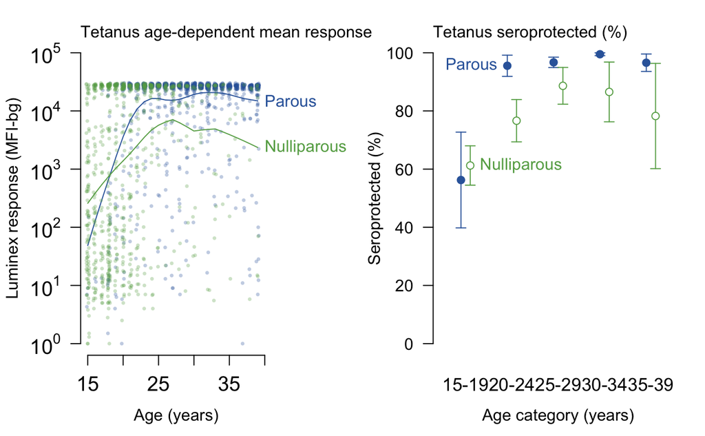

```r
lo <- layout(mat=matrix(1))
```

# Pairs Plot

This analysis summarizes the relationship between pairs of antibody responses to parasitic diseases, using means in each of the 100 sampling clusters. We subset the analysis to just 6 antibodies for parsimony in the figure. For example, there is redundancy to large degree among multiple antibodies to *W. bancrofti* (Wb123, Bm14, Bm33), which causes lymphatic filariasis. So we only included Wb123.

## Estimate cluster-level means

```r
#----------------------------------
# subset to MBA luminex MFI
# NTDs and Malaria
# exclude redudant antigens for LF
# to save space
#----------------------------------
mbavars <- c("sag2a","nie","t24","wb123","pvmsp19","pfmsp19")
mbalabs <- c('Toxoplasma\ngondii\n SAG2A','Strongyloides\nstercoralis\nNIE','Taenia\nsolium\nT24H','Lymphatic\nfilariasis\nWb123','Plasmodium\nvivax\nMSP1-19','Plasmodium\nfalciparum\nMSP1-19')
d2 <- subset(d,select=c("psuid","age",mbavars))
#----------------------------------
# count and recode values <=0 to 1
#----------------------------------
apply(d2[mbavars],2,function(x) table(x<=0) )
```

```
$sag2a

FALSE  TRUE
 2107    43

$nie

FALSE
 2150

$t24

FALSE
 2150

$wb123

FALSE
 2150

$pvmsp19

FALSE  TRUE
 2145     5

$pfmsp19

FALSE  TRUE
 2148     2
```

```r
for(vv in mbavars) {
  d2[vv][d2[vv]<=0]<-1
}
#----------------------------------
# convert values to log10 scale
#----------------------------------
for(vv in mbavars) {
  d2[vv] <- log10(d2[vv])
}
#----------------------------------
# estimate cluster-level means
#----------------------------------
cld <- d2 %>%
  group_by(psuid) %>%
  summarize_all(.,mean)
```

## Figure of results

This is Figure 2A in the manuscript. In the bottom panel, it includes correlation ellipses that provide a visual representation of the pearson correlation between cluster level means (see the `myellipse` function).

See these two articles for further motivation of the correlation ellipses (implemented in the `ellipse` package, loaded above)

Murdoch DJ, Chow ED. A Graphical Display of Large Correlation Matrices. Am Stat. 1996;50: 178–180.

Rodgers JL, Nicewander WA. Thirteen Ways to Look at the Correlation Coefficient. Am Stat. 1988;42: 59–66.

The top panel includes scatter plots between antibodies, and smooth, nonparametric locally weighted regression (loess) fits that are trimmed to avoid edge effects (see the `scatterlowess` function).

There is a hidden code chunk that saves a PDF version (download the .Rmd file from the top of this notebook for the full source code).

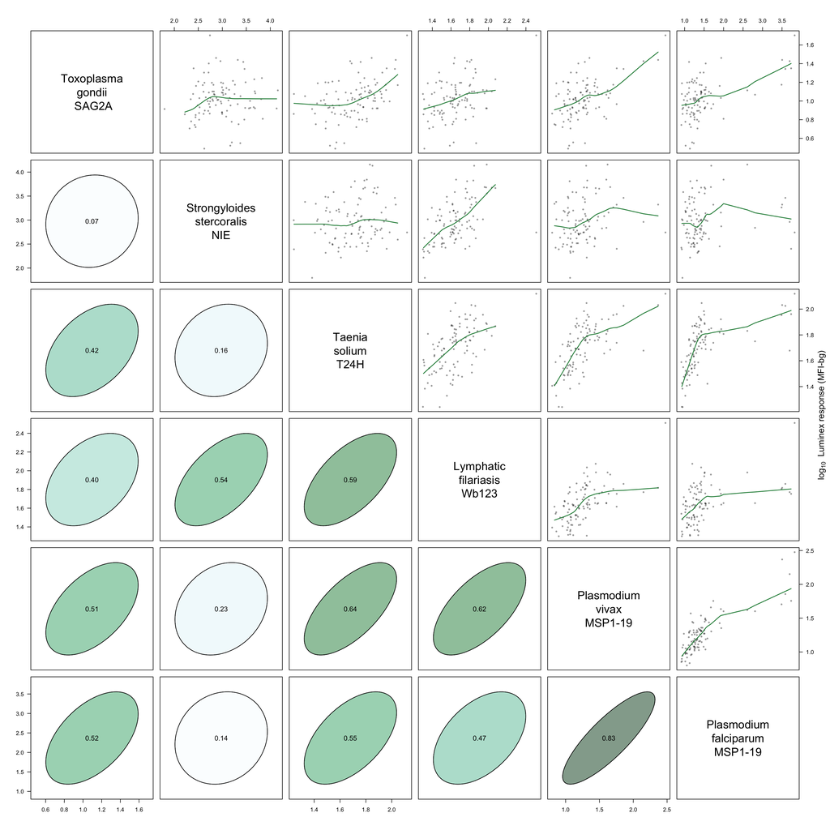

```r
# get correlations to make color categories
# (could be a better way to do this)
corrmatrix <-cor(cld[mbavars],method="pearson")
corr <-corrmatrix[upper.tri(corrmatrix)]
colgroup <-cut(corr,9,labels=F)
brewcols <- brewer.pal(9,"BuGn")
cols<-brewcols[colgroup]
## lower panel function
myellipse<-function(x,y,...){
  maxx <- max(x,na.rm=TRUE)
  minx <- min(x,na.rm=TRUE)
  maxy <- max(y,na.rm=TRUE)
  miny <- min(y,na.rm=TRUE)
  midx <- (maxx+minx)/2
  midy <- (maxy+miny)/2
  corxy <- cor(x,y,method="pearson")
  xyc <-sprintf("%1.2f",corxy)
  xyc[grep("NA",xyc)]<-""
  exy <- ellipse(corxy,centre=c(midx,midy),scale=c((maxx-minx)/6,(maxy-miny)/6))
  polygon(exy,col=alpha(cols[abs(corr-corxy)<0.0000001][1],alpha=0.5))
  lines(exy)
  if(!is.na(corxy)) {
    if(corxy<0.9) {
      text(midx,midy,xyc,cex=1.2)
    } else{
      text(maxx,midy-((maxy-miny)/3),xyc,cex=1.2,adj=1)
    }
  }

}
## upper panel function
scatterlowess<-function(x,y,...){
  points(x,y,pch=19,cex=0.5,col=alpha('black',alpha=0.3))
  # lines(lowess(y~x),col=brewcols[7])
  # drop the first and last obs to reduce edge effects
  # x and y objects from lowess are sorted by x
  lfit <- lowess(y~x)
  lines(lfit$x[-c(1,length(lfit$x))],lfit$y[-c(1,length(lfit$x))],col=brewcols[7],lwd=1.5)
}
## pairs plot
pairs(cld[mbavars],labels=mbalabs,cex=0.5,las=1,
      upper.panel=scatterlowess,
      lower.panel=myellipse
      )
mtext(expression(paste(log[10],"  Luminex response (MFI-bg)")),side=4,line=0.9)
```

# Heatmap

This section of the analysis creates a heatmap of cluster-level mean antibody levels (log10 scale). The rows of the heatmap are different antibodies, and the columns are individual sampling clusters. The sampling clusters are stratified by the 5 regions of the country (which drove the original design), and within region they are sorted by the mean antibody level across the parasitic diseases.

## Calculate means

```r
#----------------------------------
# subset data to antibodies
#----------------------------------
mbavars <- c("ttmb","sag2a","nie","t24","wb123","bm14","bm33","pvmsp19","pfmsp19")
d3 <- subset(d,select=c("region","psuid",mbavars))
#----------------------------------
# count and recode values <=0 to 1
#----------------------------------
apply(d3[mbavars],2,function(x) table(x<=0) )
```

```
$ttmb

FALSE
 2150

$sag2a

FALSE  TRUE
 2107    43

$nie

FALSE
 2150

$t24

FALSE
 2150

$wb123

FALSE
 2150

$bm14

FALSE  TRUE
 2144     6

$bm33

FALSE  TRUE
 2137    13

$pvmsp19

FALSE  TRUE
 2145     5

$pfmsp19

FALSE  TRUE
 2148     2
```

```r
for(vv in mbavars) {
  d3[vv][d[vv]<=0]<-1
}
#----------------------------------
# convert values to log10 scale
#----------------------------------
for(vv in mbavars) {
  d3[vv] <- log10(d3[vv])
}
#----------------------------------
# group data by region and cluster
# estimate means
#----------------------------------
d4 <- d3 %>%
  group_by(region,psuid) %>%
  summarize_all(mean)
#----------------------------------
# calculate mean antibody response
# (used for sorting indivs in heatmap)
# exclude tetanus since scale for
# tetanus is reversed (want high mfi)
#----------------------------------
d4$abmean <- rowMeans(d4[mbavars[!(mbavars %in% "ttmb")]])
d4 <- d4 %>%
  group_by(region) %>%
  arrange(region,abmean) %>%
  mutate(indivrank = 1:n())
#----------------------------------
# gather data into long format
# for plotting, and sort by
#----------------------------------
dlong <- gather(d4,antigen,mfi,-region,-psuid,-abmean,-indivrank)  %>%
  arrange(region,indivrank)
#----------------------------------
# format factors for plotting
#----------------------------------
levels(dlong$region) <- c("Phnom Penh","Southeast","Southwest","West","North")
Abnames <- c("Tetanus toxiod",
             "Toxoplasma gondii SAG2A",
             "Strongyloides stercoralis NIE",
             "Taenia solium T24H",
             "Lymphatic filariasis Wb123",
             "Lymphatic filariasis Bm14",
             "Lymphatic filariasis Bm33",
             "Plasmodium vivax MSP-1(19)",
             "Plasmodium falciparum MSP1(19)")
dlong$ab <- factor(dlong$antigen,levels=rev(mbavars),labels=rev(Abnames))
dlong$abgroup <- factor(NA,levels=c("VPDs","Malaria","NTDs"))
dlong$abgroup[dlong$antigen %in% c("ttmb")] <-"VPDs"
dlong$abgroup[dlong$antigen %in% c("pvmsp19","pfmsp19")] <-"Malaria"
dlong$abgroup[dlong$antigen %in% c("sag2a","nie","t24","wb123","bm14","bm33")] <-"NTDs"
```

## Figure of results

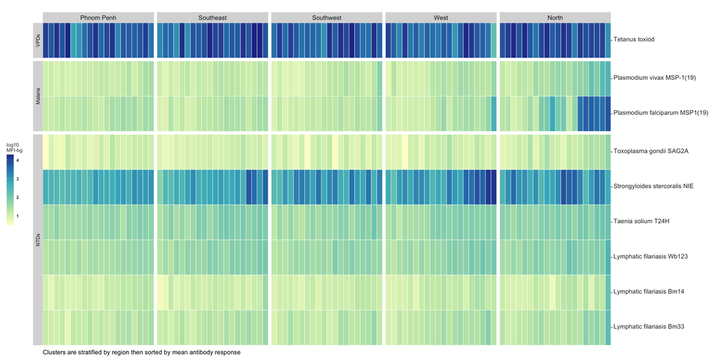

```r
#----------------------------------
# make a heatmap of all antigens
# inspiration: http://www.roymfrancis.com/a-guide-to-elegant-tiled-heatmaps-in-r/
#----------------------------------
#define a colour for fonts
textcol <- "grey20"
p <- ggplot(dlong,aes(x=indivrank,y=ab,fill=mfi)) +
  #facet over village
  facet_grid(abgroup~region,scales='free',space='free',switch="y")+

  #add border white colour of line thickness 0.25
  geom_tile(colour="white",size=0.25)+
  #remove y axis labels,
  labs(x="Clusters are stratified by region then sorted by mean antibody response",y="",title="")+
  #remove extra space
  scale_y_discrete(expand=c(0,0),position="right")+
  scale_x_continuous(expand=c(0,0))+
  # scale_x_discrete(expand=c(0,0),
  #                  breaks=1:9,labels=1:9)+
  #change the scale_fill_manual
  scale_fill_distiller(palette="YlGnBu",na.value="grey90",
                       direction=0,
                       guide=guide_colorbar(title="log10\nMFI-bg",face='bold'))+
  # scale_fill_manual(values=rev(brewer.pal(7,"YlGnBu")),na.value="grey90",guide=guide_colorbar(title="log10\nMFI-bg",face='bold'))+
  #one unit on x-axis is equal to one unit on y-axis.
  #equal aspect ratio x and y axis
  coord_equal()+
  #set base size for all font elements
  theme_grey(base_size=10)+
  #theme options
  theme(

    legend.title=element_text(color=textcol,size=8),
    legend.position = "left",
    #change legend text properties
    legend.text=element_text(colour=textcol,size=7,face="bold"),
    #change legend key height
    legend.key.height=grid::unit(0.8,"cm"),
    #set a slim legend
    legend.key.width=grid::unit(0.4,"cm"),

    #set remove x axis ticks
    axis.title.x=element_text(hjust=0),
    axis.text.x = element_blank(),
    axis.ticks.x = element_blank(),
    #set y axis text colour and adjust vertical justification
    axis.text.y=element_text(size=10,vjust = 0.2,colour=textcol),
    #change axis ticks thickness
    axis.ticks=element_line(size=0.4),

    #change title font, size, colour and justification
    plot.title=element_text(colour=textcol,hjust=0,size=12,face="bold"),
    #adjust facet labels
    strip.text.x = element_text(size=10),
    strip.text.y = element_text(size=8),
    #remove plot background
    plot.background=element_blank(),
    #remove plot border
    panel.border=element_blank(),
    #remove plot margins
    # plot.margin=margin(grid::unit(1,"cm"))
  )
p
```

```r
# save a PDF file for manuscript
ggsave(filename="~/serosurveillance-cambodia/results/cambodia-Ab-heatmap-clusters.pdf",plot = p,device='pdf',width=13,height=4)
```